# Homework 1: Power analysis

Gera Perez

10/10/2019

In this report we aim to show a good estimate on a sample size that has a reasonable level of precision for a survey. The survey will randomly choose a collection of people with full-time work and be asked on their miles for commuting. The areas in Oregon for the survey are Eugene and Springfield. The interest in this survey is to find out the mean of number of miles traveled and if people travel longer distances due to living in a different city. Here we use a power analysis by simulation and use an exponential distribution for distances traveled to figure out how many people to ask to achieve good precision.

To get a good estimate for an accurate mean of number of miles traveled in Eugene, we first looked on the Eugene Oregon geographical map. The United States Census Bureau states that Eugene has an area of 43.72 square miles. We figure that around the square root of this value, resulting to 6.6 miles, seems a reasonable distance to commute. So, we set our mean number of miles to be 6.6 miles. In addition, the United States Census Bureau states that the Eugene population in 2017 was 168,916. We figured that half of these individuals work and commute. So, we set our commuters to be 80000. Furthermore, we used this same approach for Springfield, 3.97 for the mean number of miles and 30000 for commuters. We used 200 sample sets that range from 20 to 2000. We then followed the power analysis simulation using exponential distribution.

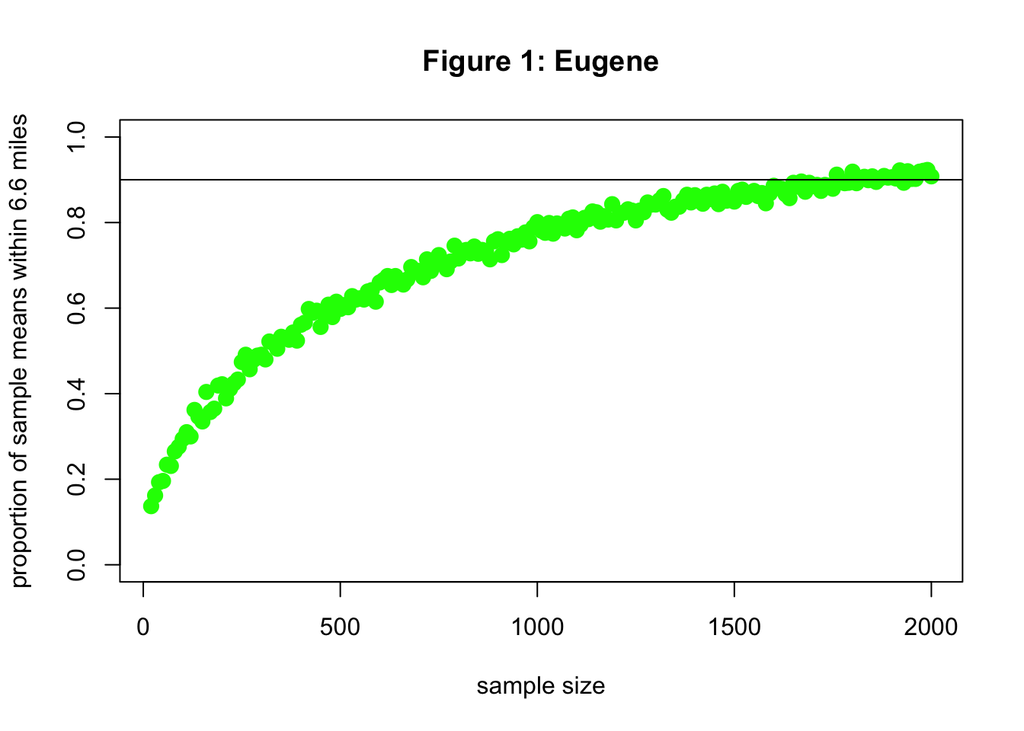

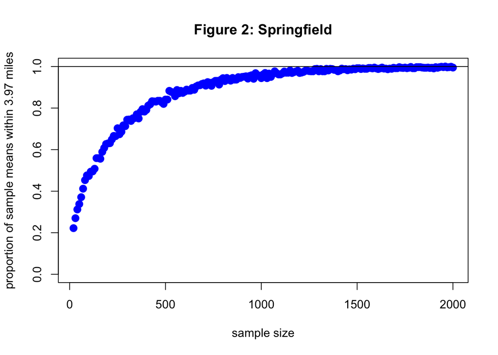

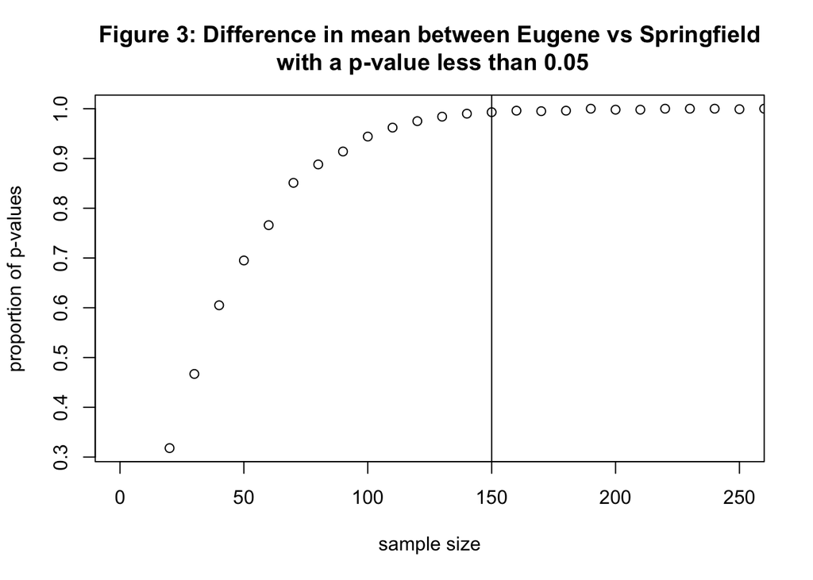

References

“US Gazetteer files 2010”. United States Census Bureau. Archived from the original on January 12, 2012. Retrieved December 21, 2012.